# **성향점수매칭(PSM)을 통한 음주와 고혈압간의 인과관계 추정**

## 1. 프로젝트 배경

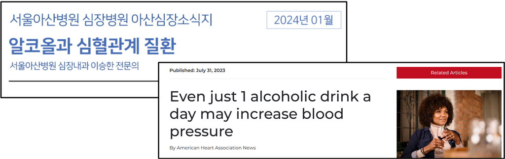

음주와 혈압·심혈관계 질환의 관련성을 다룬 국내외 보도 (서울아산병원 심장소식지, American Heart Association).

일반적으로 음주는 혈압 상승을 유발하여 고혈압의 위험을 증가시킬 것이라고 직관적으로 예상된다. 실제로 American Heart Association(AHA, 미국심장협회)의 보고에 따르면, 하루 한 잔 수준의 적은 음주라도 혈압을 상승시킬 수 있다고 알려져 있다.

그러나 한편으로는 일부 연구에서 소량의 음주가 오히려 혈압을 낮추거나 고혈압과 뚜렷한 연관이 없다는 결과를 제시하기도 한다. 이처럼 기존 연구에서는 음주와 혈압 사이의 관계에 대해 상반된 결론이 존재한다.

본 분석에서는 한국인유전체역학조사(KoGES) 데이터를 활용하여 음주 여부가 고혈압 병력에 어떤 영향을 미치는지를 검토하고자 한다. 단순한 상관관계를 넘어, 관찰연구의 한계를 보완하기 위해 성향점수매칭(PSM)을 사용하여 교란변수를 통제한 뒤 보다 인과적인 관점에서 음주의 영향을 추정하는 것을 목표로 한다.

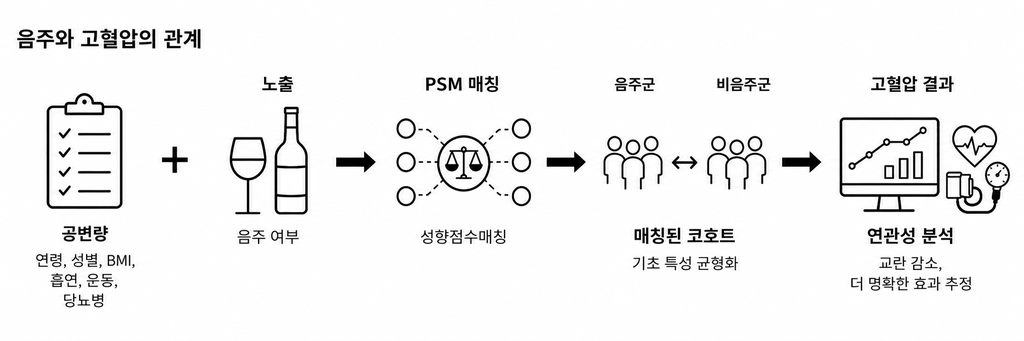

성향점수매칭(PSM) 분석 개요 — 공변량과 음주 노출을 성향점수로 매칭해 교란을 통제한 뒤 고혈압 결과를 비교한다.

## 2. 데이터 설명

데이터 출처: 한국인유전체역학조사(KoGES)연구 목적: 유전적요인과 환경요인의 상호작용을 통해 만성질환(고혈압, 당뇨 등) 규명표본 구성: 무작위로 선정된 한국인 1,000명활용 목적: 유전·환경요인이 만성질환에 미치는 영향 분석

### **2.1 변수설명**

표 1. 분석에 사용된 변수 (n = 1,000)

[output not shown]

### **2.2 데이터 형태**

|  | T00_ID | T01_DRINK | T01_HTN | T01_AGE | T00_SEX | T01_EXER | T01_WEIGHT | T01_WAIST | T01_HBA1C | T01_GLU0 | T01_TCHL | T01_HDL | T01_TG | T01_FMFHT | T01_FMMHT |
| --- | --- | --- | --- | --- | --- | --- | --- | --- | --- | --- | --- | --- | --- | --- | --- |
| 0 | K_FOLLOW_0001 | 3 | 1 | 56 | 1 | 1 | 50 | 71 | 5.6 | 82 | 154 | 35 | 126 | 1 | 1 |
| 1 | K_FOLLOW_0002 | 3 | 1 | 40 | 1 | 1 | 94 | 100 | 5.5 | 130 | 214 | 44 | 169 | 1 | 1 |
| 2 | K_FOLLOW_0003 | 2 | 2 | 52 | 1 | 1 | 63 | 86 | 5.2 | 83 | 130 | 27 | 134 | 1 | 1 |
| 3 | K_FOLLOW_0004 | 1 | 1 | 60 | 2 | 1 | 70 | 103 | 5.6 | 89 | 182 | 47 | 123 | 1 | 1 |
| 4 | K_FOLLOW_0005 | 3 | 1 | 49 | 1 | 1 | 69 | 82 | 6.9 | 95 | 203 | 36 | 277 | 1 | 1 |
| ... | ... | ... | ... | ... | ... | ... | ... | ... | ... | ... | ... | ... | ... | ... | ... |
| 995 | K_FOLLOW_0996 | 1 | 1 | 64 | 1 | 1 | 55 | 76 | 5.7 | 75 | 151 | 36 | 176 | 1 | 1 |
| 996 | K_FOLLOW_0997 | 3 | 1 | 63 | 1 | 1 | 76 | 81 | 66666 | 96 | 149 | 33 | 114 | 1 | 1 |
| 997 | K_FOLLOW_0998 | 3 | 1 | 41 | 1 | 1 | 74 | 81 | 5.6 | 89 | 273 | 36 | 83 | 1 | 1 |
| 998 | K_FOLLOW_0999 | 3 | 2 | 69 | 2 | 2 | 44 | 72 | 66666 | 88 | 206 | 43 | 210 | 2 | 1 |
| 999 | K_FOLLOW_1000 | 1 | 1 | 45 | 2 | 1 | 76 | 87 | 5.6 | 84 | 239 | 44 | 174 | 1 | 1 |

1000 rows × 15 columns

## 3. EDA(탐색적 데이터 분석)

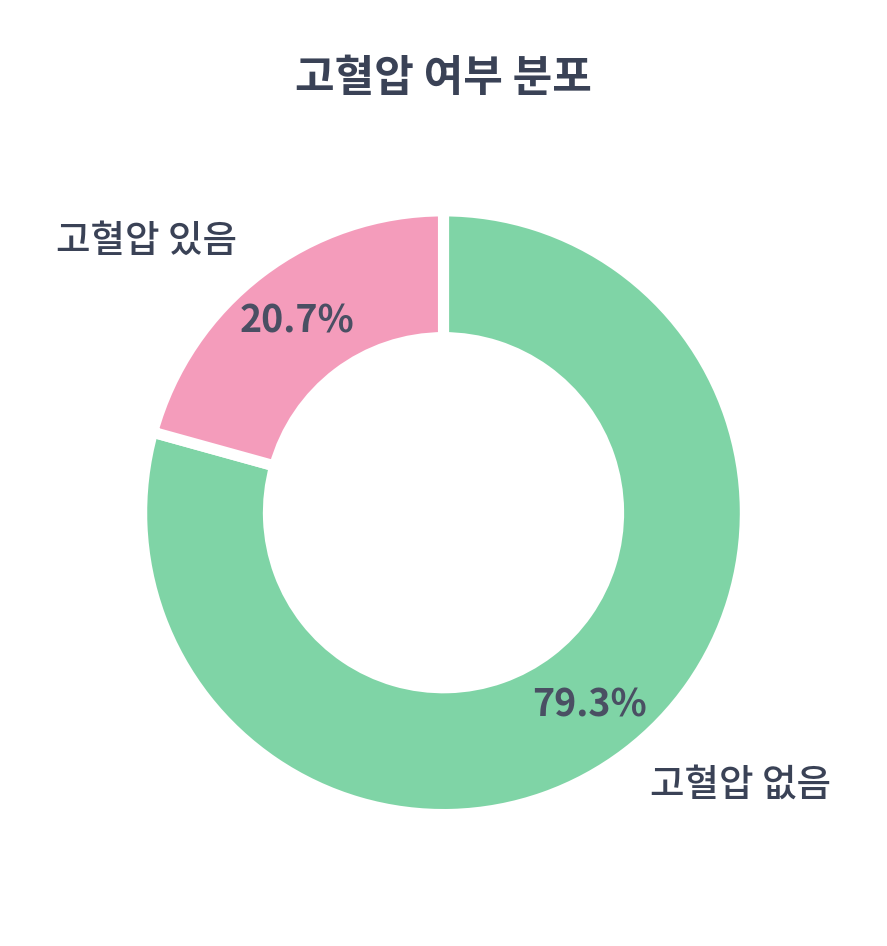

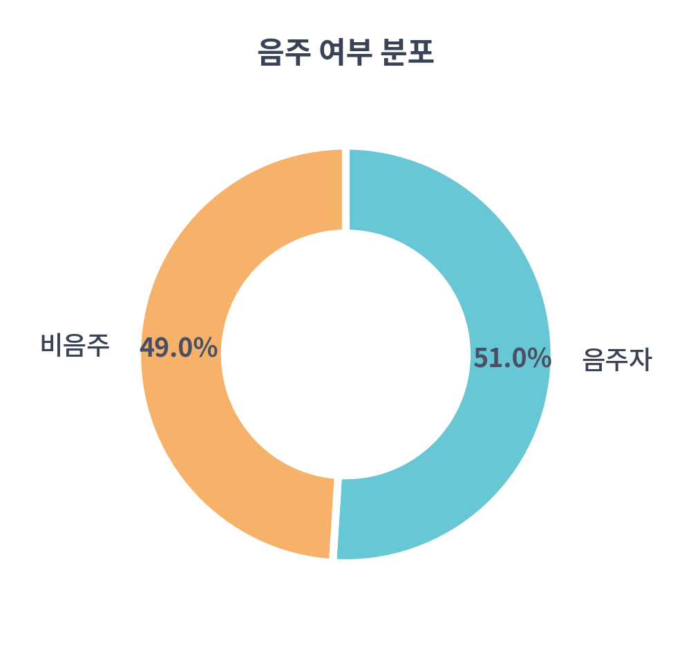

고혈압 여부 분포를 보면, 전체의 약 79%는 고혈압 병력이 없었으며 약 21%는 고혈압 병력이 있었다.

음주 여부는 비음주자와 음주자가 거의 비슷한 비율(49% vs 51%)로 분포하여 두 집단 규모가 균형적이다.

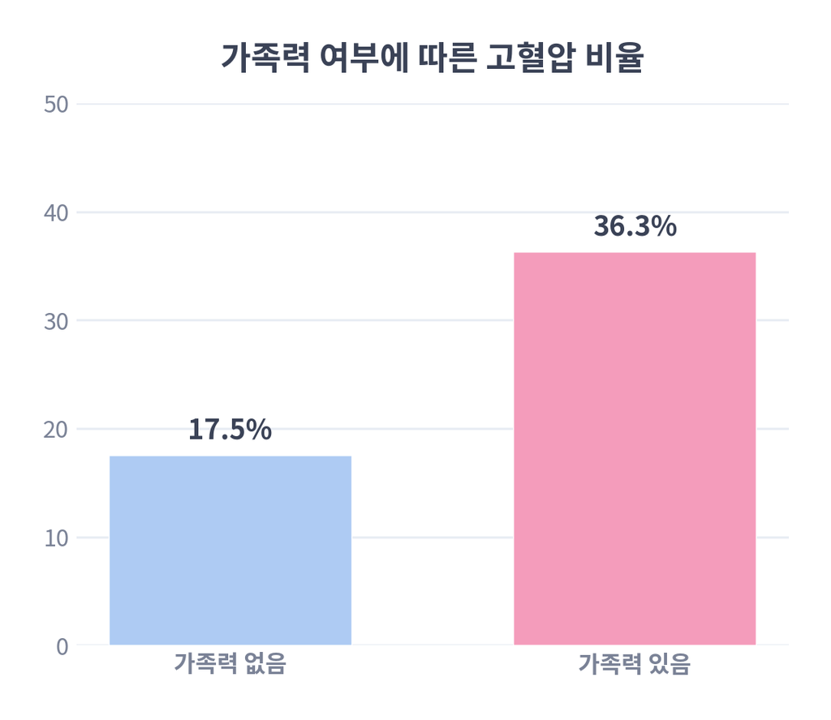

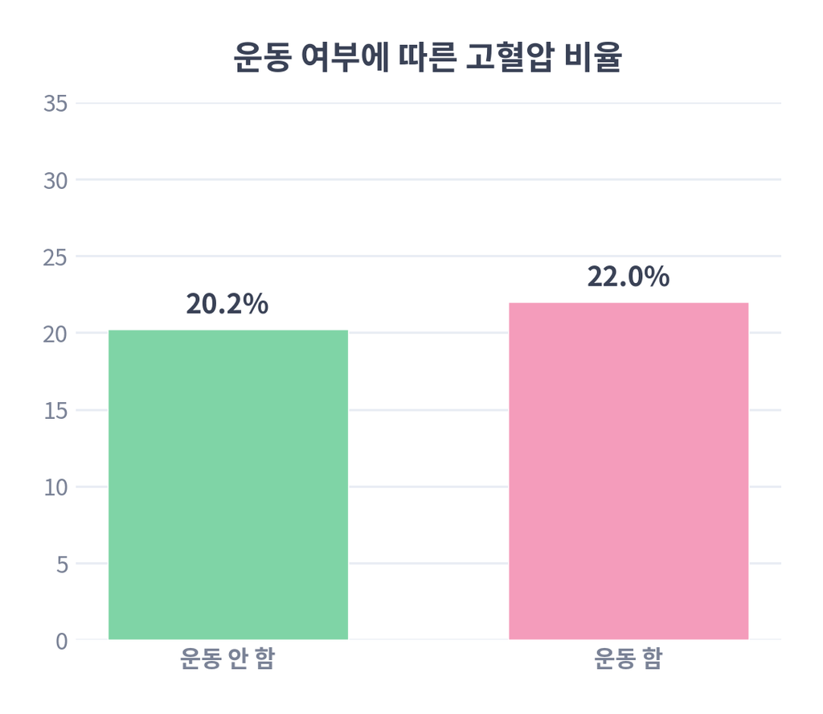

가족력이 있는 경우 고혈압 비율은 약 36%로, 가족력이 없는 경우(약 18%)보다 두 배가량 높게 나타났다.

운동 여부에서는 운동을 하는 집단이 약간 더 높은 고혈압 비율을 보이나, 두 집단 간 차이는 크지 않은 수준이었다.

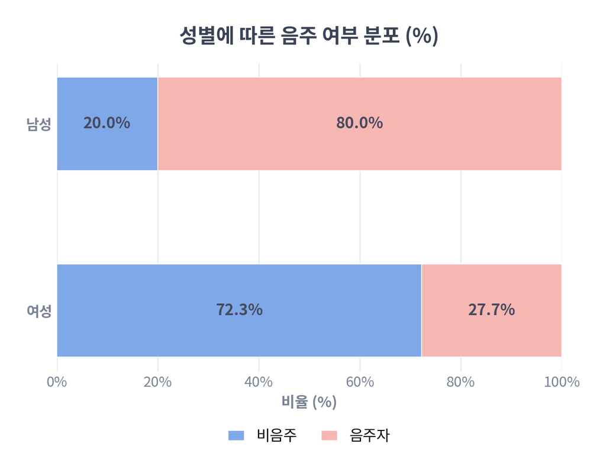

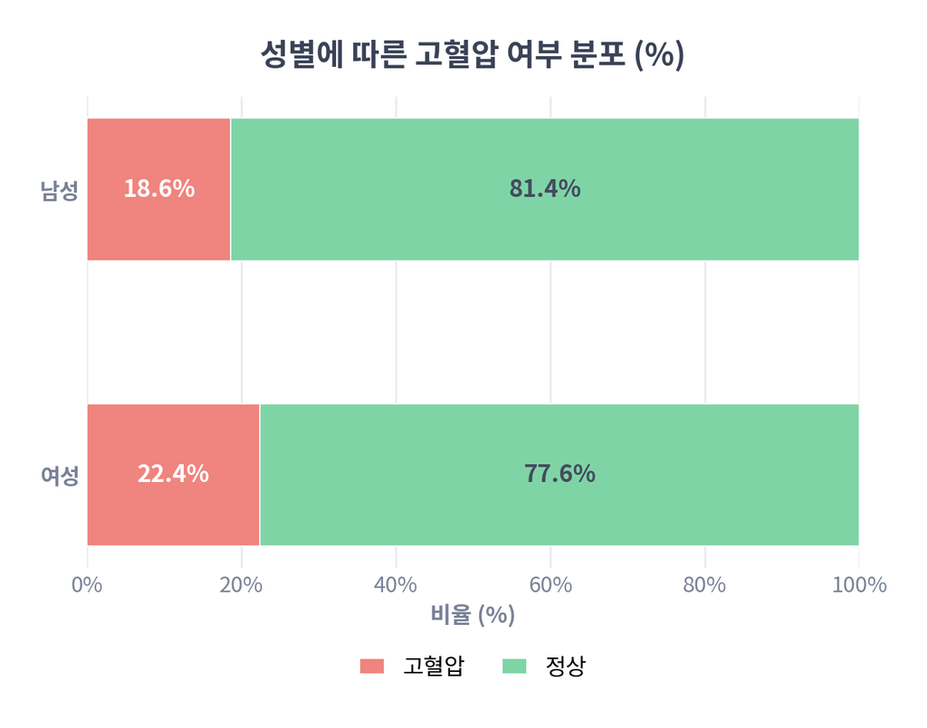

여성은 비음주 비율이 높고 남성은 음주자 비율이 크게 높아, 음주 행동에서 뚜렷한 성별 차이가 나타났다.

성별에 따른 고혈압에서는 여성이 약간 더 높은 고혈압 비율을 보였다.

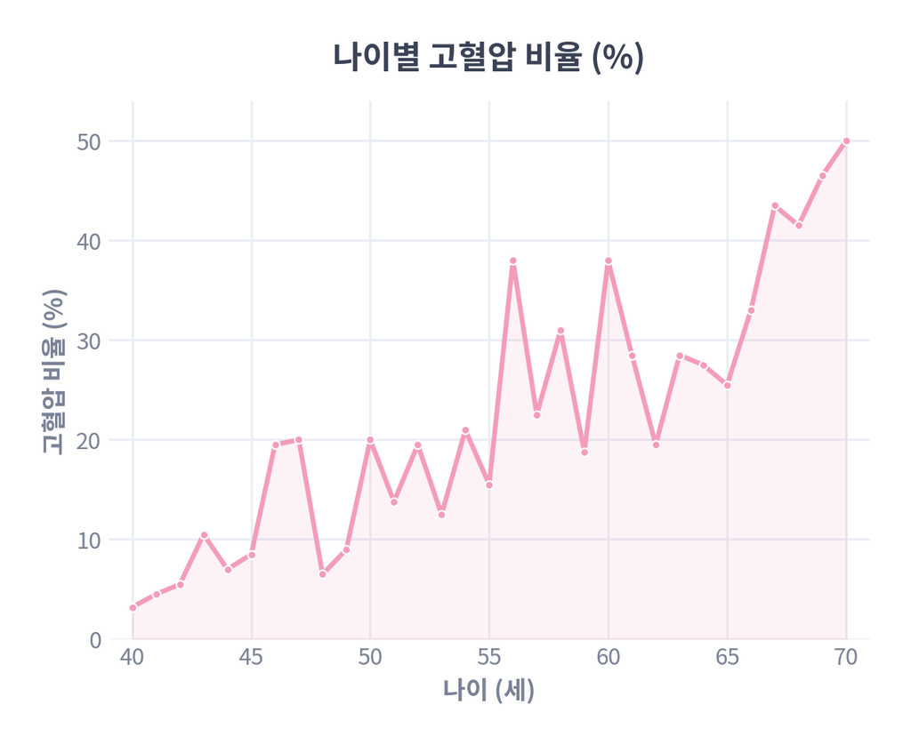

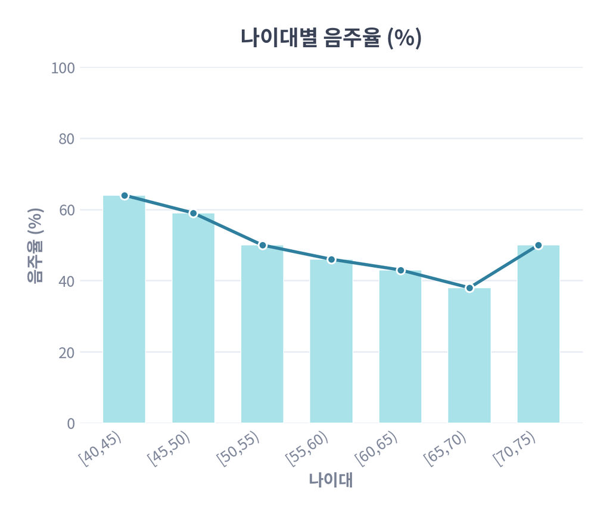

나이별 고혈압 비율 40대 초반에서는 고혈압 비율이 5-10% 수준으로 낮지만, 나이가 증가할수록 꾸준히 상승하여 60대 후반에서는 40~50%까지 높아진다. 즉, 고혈압은 나이가 들수록 뚜렷하게 증가하는 연령 의존적 패턴을 보인다.

나이대별 음주율 음주율은 40대에서 가장 높고, 연령이 증가할수록 점진적으로 감소해 60대 후반에서 최소치를 보인다. 즉, 연령이 높아질수록 음주 비율은 낮아지는 반면 고혈압 비율은 증가하는 상반된 경향을 확인할 수 있다.

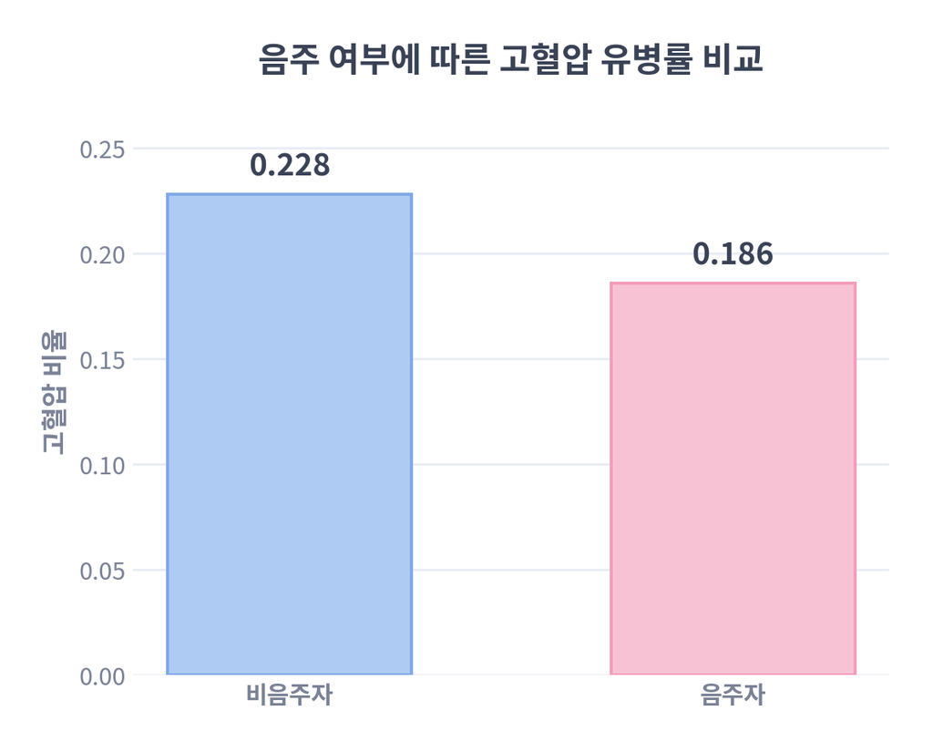

표 2. 음주 여부에 따른 고혈압 유병률 평균 비교

| 구분 | 고혈압 비율 |
| --- | --- |
| 비음주자 | 0.228 |
| 음주자 | 0.186 |
| 단순 평균차 (Naive ATE) | −0.042 |

비음주자의 고혈압 비율은 약 22.8%, 음주자의 고혈압 비율은 약 18.6%로 나타났다.

두 집단의 단순 평균 차이(Naive ATE)는 약 –4.2%p로, 음주자의 고혈압 비율이 더 낮게 관찰된다.

하지만 이 값은 연령, 성별, 체중, 대사 지표 등 여러 교란변수(confounders)를 통제하지 않은 단순 비교이기 때문에, 실제 인과적 효과를 반영한다고 보기 어렵다.

즉, 음주 여부만으로 고혈압의 원인을 해석하기에는 부적절하며 추가적인 보정이 필요하다.

## **4. 데이터 분석**

### **4.1 방법론**

본 분석에서는 음주 여부가 고혈압에 미치는 인과적 효과를 보다 정확하게 추정하기 위해 매칭(Matching) 기법을 적용하였다. 다양한 매칭 방법 중에서는, 공변량을 기반으로 처치를 받을 확률을 추정한 뒤 유사한 성향점수를 가진 개체끼리 비교하는 성향점수 매칭(Propensity Score Matching, PSM)을 사용하였다. 이를 통해 음주군과 비음주군의 기저 특성 차이를 보정하고, 보다 공정한 처치 효과 추정이 가능하도록 하였다.

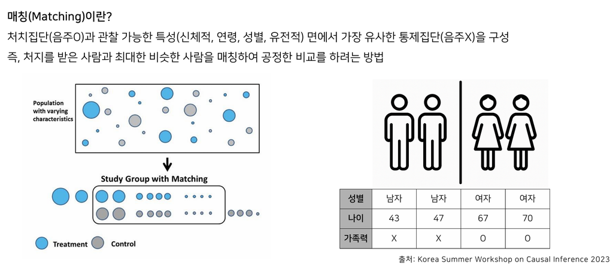

#### **4.1.1 매칭(Matching)**

매칭은 처치집단(예: 음주자)과 관찰 가능한 특성(신체적, 연령, 성별, 유전적 요인 등)이 최대한 유사한 통제집단(예: 비음주자)을 구성하여, 두 집단 간 공정하고 의미 있는 비교를 수행하기 위한 방법이다.

즉, 처치를 받은 사람과 받지 않은 사람의 사전 특성 차이를 줄여, 효과를 비교할 때 처치 자체의 영향만 남기기 위한 설계 기반 인과추론 기법이다.

그림에서도 볼 수 있듯이, 전체 모집단에서 다양한 특성을 가진 사람들 중에서 처치군과 가장 비슷한 사람들만 추려 균형 잡힌 비교 그룹을 만드는 과정이라고 이해할 수 있다.

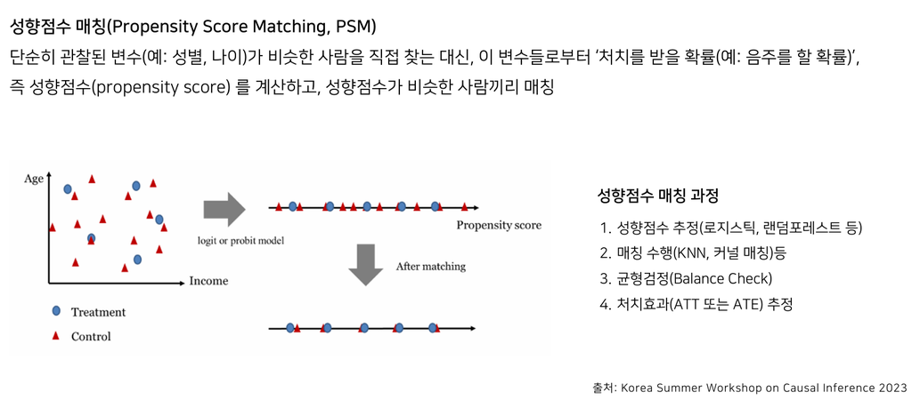

#### **4.1.2 성향점수 매칭 (Propensity Score Matching, PSM)**

성향점수 매칭은 전통적 매칭처럼 특성(성별, 나이 등)이 동일한 사람을 직접 매칭하는 방식이 아니라, 각 사람의 처치를 받을 확률(예: 음주할 확률)을 계산한 뒤 이 점수(Propensity Score)가 비슷한 사람들끼리 매칭하는 방법이다.

성향점수는 보통 로지스틱 회귀나 랜덤포레스트 등의 모델을 사용해 계산하며, 이 점수가 유사한 사람들끼리 짝지음으로써 처치군과 통제군의 기저 특성을 균형 있게 맞출 수 있다.

예를 들어 연령과 소득 수준이 다양한 집단에서, 처치 여부를 예측하는 성향점수를 추정한 뒤, 유사한 점수를 가진 사람들끼리 매칭하면 다차원적인 특성 차이를 한 번에 조정할 수 있다는 장점이 있다.

### **4.2 PSM 매칭 적용**

#### **4.2.1 성향점수 추정 및 매칭**

로지스틱 회귀분석을 통해 공변량(성별,나이등)이 처치(음주여부)를 받을 확률을 예측하는 모형을 적합해 성향점수를 추정

이를 통해 성향점수는 0~1사이의 확률값으로 산출,점수의 의미는 처치를 받을 확률(음주를할확률)

매칭은 KNN 기반의 최근접 매칭(nearest neighbor matching)을 사용하였으며, 단일 매칭을 위해 k=1로 설정하여 각 처치군 개체와 성향점수가 가장 유사한 통제군 개체를 1:1로 대응시켰다.

#### **4.2.2 균형점검**

성향점수매칭(PSM)의 적절성을 평가하기 위해 매칭 전후 성향점수 분포를 비교하여 균형을 점검하였다.

매칭 이전에는 음주자와 비음주자 간의 성향점수 분포가 뚜렷하게 달라 두 집단이 체계적으로 차이가 나는 것으로 나타났다.

매칭 이후에는 두 집단의 분포가 거의 동일한 형태로 수렴하여, 매칭이 적절히 수행된 것을 확인하였다

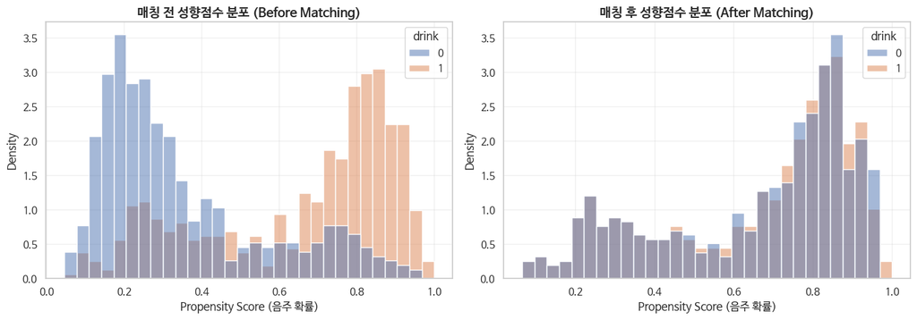

Love Plot은 성향점수 매칭(PSM)에서 ‘매칭 전후 공변량 균형(covariate balance)’을 시각적으로 확인하기 위한 그래프이다.

각 공변량에 대해 표준화 평균차이(Standardized Mean Difference, SMD) 를 계산한 후, 매칭 전(Unadjusted)과 매칭 후(Adjusted)의 값을 나란히 비교함으로써 두 집단(처치군 vs 대조군)이 얼마나 유사해졌는지를 직관적으로 평가하는 데 사용된다.

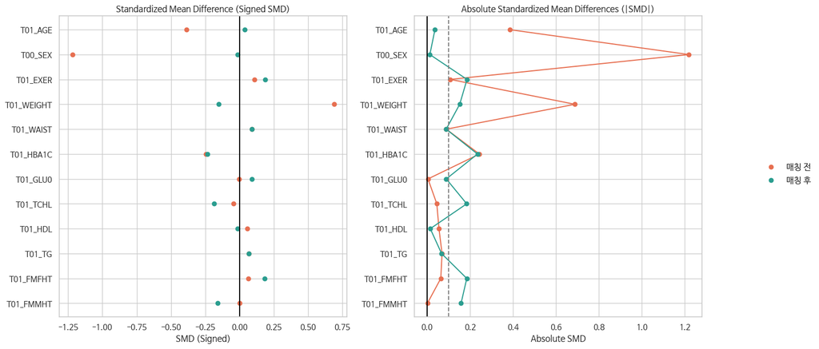

왼쪽 그래프는 SMD의 부호(+/-)까지 반영하여 어떤 집단에서 평균이 더 높은지 차이가 어느 정도인지 를 보여준다.

여러 공변량에서 SMD 값이 0.2–1.2 수준까지 커서, 처치군(음주자)과 대조군(비음주자)이 처음부터 매우 다른 집단이었음을 의미한다.

→ 즉, 매칭 전에는 교란이 상당히 존재했다는 뜻이다.

#### **4.2.3 ATE(Average Treatment Effect, 평균 처치 효과) 추정**

매칭 후 매칭된 각 쌍(음주O 사람, 음주X 사람)의 결과 차이의 평균을 구해 ATE(평균처치효과)추정

\[ \widehat{ATE}_{\text{match}} = \frac{1}{N} \sum_{i=1}^{N} \left( Y_{T_i} - Y_{C_i} \right) \]

여기서 \(N\)은 매칭된 처치집단의 표본 수를 의미하며, \(Y_i^T\)는 음주자 \(i\)의 고혈압 발생 여부, \(Y_i^C\)는 해당 음주자와 성향점수가 유사하게 매칭된 비음주자의 고혈압 발생 여부를 나타낸다. 고혈압 발생 여부는 발생한 경우 1, 발생하지 않은 경우 0으로 정의하였다.

따라서 각 매칭 쌍에서 음주자와 비음주자의 고혈압 발생 여부 차이인 \((Y_i^T-Y_i^C)\)를 계산한 후, 이를 전체 매칭 표본에 대해 평균하여 음주가 고혈압 발생에 미치는 평균처치효과를 추정하였다. 추정된 ATE가 양수이면 음주가 고혈압 발생 위험을 증가시키는 방향으로 작용했음을 의미하며, 음수이면 반대로 고혈압 발생 위험을 감소시키는 방향으로 작용했음을 의미한다.

표 3. 성향점수매칭(PSM) 결과

| 구분 | 값 |
| --- | --- |
| 매칭 후 샘플 수 | 1,012 (처치 506 / 대조 506) |
| PSM 기반 추정 ATE (음주 → 고혈압) | 0.0474 |

**추정된** **ATE** **값은** **0.048이다.**

매칭 분석 결과, 음주의 효과로 인한 고혈압 발생 위험은 약 4.8%p 증가하는 것으로 해석할 수 있다.

매칭 이전에는 음주자의 고혈압 유병률이 비음주자보다 4.2%p 낮게 나타나, 단순 비교에서는 음주가 오히려 고혈압 위험을 감소시키는 것처럼 보였다. 그러나 교란변수를 통제한 매칭 이후에는, 음주자의 고혈압 유병률이 비음주자보다 4.8%p 높아지는 것으로 역전되었다.

이는 초기의 단순 비교 결과가 연령, 성별, 생활습관, 대사지표 등과 같은 잠재적 교란에 의해 왜곡되었음을 의미하며, 교란을 제거한 후에는 음주가 실제로 고혈압 위험요인으로 작용할 가능성이 높다는 점을 시사한다.

#### **4.2.4 Bootstrap을 사용한 분산 추정 및 신뢰구간 추정**

부트스트랩으로 재추정한 평균도 거의 동일한 값(4.7%p).

추정의 일관성이 높다는 것을 의미

신뢰구간 하한(약 0.0004)이 0을 초과함 → 0을 포함하지 않음

음주가 고혈압 발생률에 미치는 효과가 통계적으로 유의함(p < 0.05)

즉, 단순히 우연으로 나타난 차이가 아니라 실제 효과가 존재할 가능성이 높음

```
ATE (Matched diff): 0.047430830039525695
Bootstrap 평균: 0.04708413405320972
Bootstrap 표준오차(SE): 0.023796537974442544
```

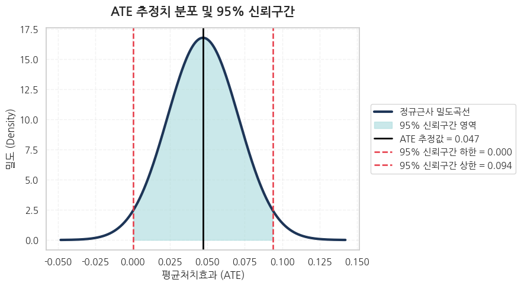

## **5. 결론**

본 연구에서는 성향점수매칭(PSM)을 활용해 음주가 고혈압에 미치는 인과적 영향을 추정하였다.

단순 비교(비조정)에서는 오히려 음주자의 고혈압 유병률이 비음주자보다 낮아 음의 효과가 나타났으나, 교란변수를 통제하고 공정한 비교가 가능하도록 매칭을 수행한 결과, 추정된 ATE는 약 +4.8%p로 양의 영향으로 역전되었다.

이는 교란변수로 인해 왜곡되었던 효과가 보정 후 올바르게 드러났음을 의미하며, 음주가 실제로 고혈압 위험을 증가시킬 가능성을 시사한다.

## **6. 참고문헌**

American Heart Association News. (2023, July 31). *Even just 1 alcoholic drink a day may increase blood pressure*. American Heart Association.  
https://www.heart.org/en/news/2023/07/31/even-just-1-alcoholic-drink-a-day-may-increase-blood-pressure

이승한. (2024). 「알코올과 심혈관계 질환」. 『아산심장소식지』, 2024년 1월호. 서울아산병원 심장병원.  
https://www.amc.seoul.kr/asan/depts/heart/K/bbsDetail.do?menuId=4634&contentId=264002